Hello welcome to my repo for hw09:)

Structure of my pipeline:

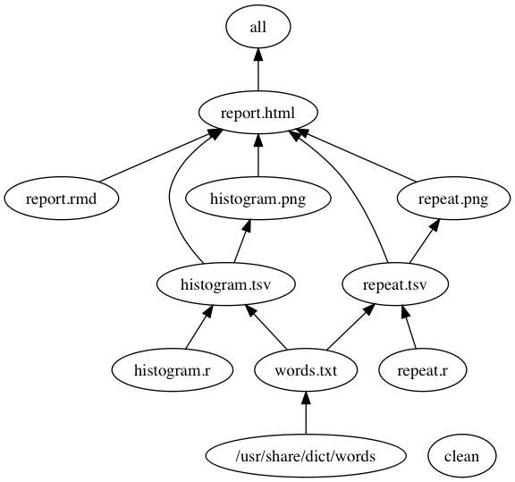

Changes I’ve made: * Write a new R script to find the times of letters appearance repeated in a word * Write a new Rmd file to plot the result * Change the Makefile * Making a graph of my pipeline

# make-activity

The commit history of this repository reflects what a student might do as she works through [this activity](http://stat545-ubc.github.io/automation04_make-activity.html) from [STAT 545](http://stat545-ubc.github.io). This fully developed example shows:

- How to run an R script non-interactively
- How to use `make`
  - to record which files are inputs vs. intermediates vs. outputs
  - to capture how scripts and commands convert inputs to outputs
  - to re-run parts of an analysis that are out-of-date
- The intersection of R and `make`, i.e. how to
  - run snippets of R code
  - run an entire R script
  - render an R Markdown document (or R script)
- The interface between RStudio and `make`
- How to use `make` from the shell
- How Git facilitates the process of building a pipeline